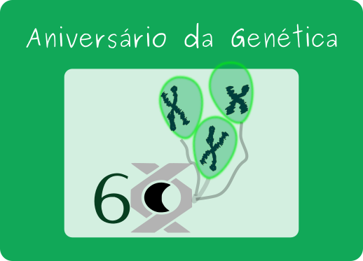

# Apresentação

As atividades de estudo de genética na ESALQ começaram oficialmente em 1936 com a criação da cadeira de Citologia e Genética ocupada pelo prof. Friedrich Gustav Brieger. E em 1958 ocorreu a criação do Instituto de Genética.

Para comemorar os 60 anos da criação do Instituto, que mais tarde se tornou o Departamento de Genética, o grupo de Divulgação Científica GENt convida alunos, funcionários e professores para uma sessão de cinema que vai contar um pouquinho da nossa história!

Para isso, vamos assistir ao documentário “Histórias da Genética no Brasil”, que conta com importantes entrevistados para a área da Genética, como os professores João Lúcio de Azevedo, Roland Vencovsky e Warwick Kerr.

Venha participar, comer uma pipoca com guaraná e comemorar o aniversário do Departamento de Genética com a GENt! Traga sua caneca!

# Saiba mais sobre alguns dos personagens da história do departamento

Se você frequenta o departamento de genética da ESALQ já deve ter reparado em alguma das placas metálica com o nome e imagem de um pesquisador. Pois é… cada sala do departamento homenageia um pesquisador que deu contribuições importantes para a história do departamento.

Nesse aniversário, além da exposição do filme, o grupo GENt também quer dar maior visibilidade a essas personalidades. Procuramos mais informações sobre esses pesquisadores, através de pesquisas e entrevistas aos professores Gerhard Bandel, Giancarlo Conde Xavier Oliveira, João Lúcio de Azevedo e Margarida Lopes Rodrigues de Aguiar-Perecin. Essas informações serão anexadas próximas às placas nos dias próximos ao evento, mas também ficarão disponíveis aqui. Vamos mergulhar mais um pouquinho na nossa história?

## Prof. Almiro Blumenschein

**Quem foi**: Realizou graduação e pós-graduação na ESALQ, nos anos de 1954 e 1957, respectivamente, e foi orientado pelo professor Friedrich Gustav Brieger. Fez pós-doutorado sob orientação da Barbara McClintock, na Carolina do Norte, finalizado em 1961. Atuou como professor titular do Departamento de Genética da ESALQ de 1956 a 1985 e foi responsável pelo laboratório de Citologia. Atuou também como diretor científico da EMBRAPA. Recebeu ao menos 8 premiações nacionais e internacionais.

**Contribuições**: Durante seu doutorado e livre docência, trabalhou com orquídeas e descobriu poliploidia no subgênero que estudava, através de estudos de contagem de cromossomos, e percebeu que isso possibilitava a expansão do subgênero para novos ambientes. Em parceria com Barbara McClintock, que ganhou o Prêmio Nobel em 1983, estudou os knobs heterocromáticos dos cromossomos de milho e sua variabilidade em raças de milho da América Latina. Além disso, atuou no desenvolvimento científico nacional ao colaborar com a criação de centros de pesquisa da EMBRAPA.

**Curiosidades**: Foi o primeiro chefe do Departamento de Genética após a extinção da cadeira de Citologia e Genética, com mandato de dois anos. Foi orientador de algumas figuras conhecidas nesses corredores, como o Prof. Dr. Gerhard Bandel e Profª Drª Margarida L. R. de Aguiar-Perecin.

## Prof. José Theófilo do Amaral Gurgel

**Quem foi**: Nasceu na cidade de São Manuel (SP), formou-se na ESALQ no ano de 1937 e em 1938 foi admitido como professor assistente do professor Friedrich Gustav Brieger. Lecionou no Departamento de Genética até 1971, quando se aposentou.

**Contribuições**: Trabalhou com essências florestais, como a Araucaria angustifolia, e com o melhoramento de frutíferas. Foi o primeiro a descrever a segregação do tipo 10:3:3, no caso da mamoneira. Era um dos responsáveis pelas coletas de materiais do Departamento. Foi um dos pioneiros nas pesquisas com milho, introduziu a Genética de Microrganismos e a Citogenética no Brasil. Como docente da ESALQ, sua principal bandeira foi o ensino na graduação, ministrando aulas de Biologia Celular, Genética e Melhoramento Florestal.

**Curiosidades**: Durante suas pesquisas no exterior, foi orientado por Ronald Aylmer Fisher. No departamento, orientou diversos alunos de graduação. Entre seus alunos de mestrado está o Prof. Dr. Gerhard Bandel e de doutorado o Prof. João Lucio de Azevedo. Foi o responsável por elaborar a primeira apostila de Citologia e Genética.

## Prof. Warwick Estevam Kerr

**Quem foi**: Nascido em Santana do Parnaíba, em 1922, se graduou em agronomia pela ESALQ, onde obteve também os títulos de doutor em agronomia e livre docente em Genética, atuando como professor e chefe do Departamento de Biologia. Foi o primeiro diretor científico da FAPESP e foi também diretor Diretor do Instituto Nacional de Pesquisas da Amazônia (INPA). Foi presidente da SPBC e da Sociedade Brasileira de Genética, e reitor da Universidade Estadual do Maranhão. Na Universidade Federal de Uberlândia (UFU), onde permaneceu até 2018, implantou a pós graduação em Genética e Bioquímica.

**Contribuições**: Dentre seus principais trabalhos científicos, destacam-se o trabalho sobre a determinação de castas em abelhas sem ferrão (gênero Mellipona) e o desenvolvimento de uma cultivar de alface com alto teor de vitamina A.

**Curiosidades**: Kerr tinha uma atuação política considerável. Foi vereador de Piracicaba pelo partido socialista. Durante a ditadura, criticava as políticas de tortura do governo, o que o rendeu duas prisões. Entretanto, no governo Gaisel, foi indicado para presidir o INPA. Sempre acreditou que o conhecimento deveria estar disponível para todos e por isso defendia a popularização da ciência e o acesso livre a recursos didáticos. Foi o Primeiro brasileiro a compor a academia de ciências dos Estados Unidos. Faleceu em 15 de setembro de 2018, deixando seis filhos.

## Prof. Marcílio de Souza Dias

**Quem foi**: Nasceu na cidade de São José dos Campos no ano de 1915. Em 1945 foi convidado pelo Prof. Friedrich Gustav Brieger para atuar no Departamento de Genética. Estudou melhoramento vegetal em universidades do exterior. Jânio Quadros o promoveu, visto que Marcílio não possuía doutorado formal. Talvez isso se deva ao fato de que agricultores de Mogi das Cruzes pediram ao então presidente para conceder a ele o regime de tempo integral, com aumento de salário.

**Contribuições**: Foi o introdutor das hortaliças no território brasileiro, a partir de coletas provenientes da Alemanha (por indicação do Prof. Brieger). Após trazer os materiais, adaptou-os na cidade de Campos do Jordão. Também propôs o cultivo de hortaliças em distintas regiões do país, para ser possível obtê-las durante todo o ano. Fazia cruzamentos entre plantas e avaliava o resultado. Seu principal foco era desenvolver novas variedades de hortaliças. Algumas de suas variedades eram utilizadas até recentemente na Europa.

**Curiosidades**: Chegava às 5h30 e ficava sentado na rampinha em frente ao portão da Genética e alí mesmo distribuía funções aos funcionários. Às 17h a Dona Vivi (Olívia Marques Dias), sua esposa, vinha buscá-lo, uma vez que ele não dirigia. Foi homenageado durante as comemorações de 100 anos da ESALQ devido a sua contribuição para a agricultura brasileira.

## Prof. Ernesto Paterniani

**Quem foi**: Filho de imigrantes italianos, nascido em São Paulo. Mudou-se com a família para Piracicaba e ingressou na ESALQ em 1947. Após a graduação em 1950, recebeu uma bolsa da Rockfeller Foundation e fez treinamento no México, iniciando trabalhos com melhoramento de milho. De 1952 a 1983 atuou como professor do Departamento. Recebeu 14 prêmios e condecorações.

**Contribuições**: Sob orientação do prof. Friedrich Gustav Brieger desenvolveu sua tese de doutorado sobre raças de milho nativas. Seus pós-doutorados (1957 - 1958) foram na University of Nebraska e na Iowa State University. Foi um dos grandes responsáveis por tornar a ESALQ um dos centros de referência no melhoramento. Um de seus trabalhos mais conhecidos foi quando encontrou a distância efetiva da dispersão do pólen de milho, conduzindo a seleção para o isolamento reprodutivo entre duas populações. Publicou um trabalho na revista Evolution em 1969 sobre seleção para isolamento reprodutivo por incompatibilidade de duas populações de milho.

**Curiosidades**: Notabilizou-se por seus trabalhos com milho, desenvolvendo inclusive uma coleção de milho para pesquisa e extensão. Produziu variedades de milho com nomes curiosos: Piramex, varidade com milho mexicano; Piranão - milho mais baixo, fácil de colher e Pirapoca - milho para fazer pipoca. Ocupava a sala que é hoje do Prof. Dr. Gabriel R. A. Margarido.

Você conhece esses pesquisadores ou mais algum que tenha passado pela história? Conte para nós! Nos ajude a registrar!